# Scatterplots in R using qplot()

## Scatterplots: 2 continuous variables

In this lab we’ll explore how to make scatterplots using the qplot() function in ggplot2.

### R Preliminaries

- We’ll use the qplot() function in the *ggplot* package
- The *cowplot* package provides nice deafults for ggplot IMHO

```r
library(ggplot2)
library(cowplot)
```

### Scatterplot of Iris data

- Let’s make a scatter plot, where we plot 2 continous, numeric variables against each other
- that is, both x and y variables are numbers; not categories

I’ve forgotten the names of all the iris variables, so I’ll use the **names()** command to see what they are

```r
names(iris)
```

I’ll plot the sepals against the petals

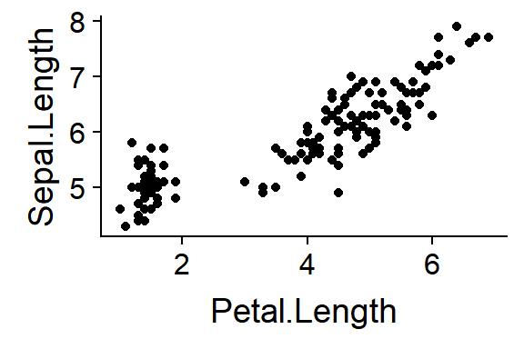

Sepals vs. Petals

```r
qplot(y = Sepal.Length,
      x = Petal.Length,
      data = iris)
```

### Scatter plot of mammal brain data

Let’s look at another dataset

#### Preliminaries

Get the data from the ggplot2 package

```r
data(msleep)
```

#### Look at the data

```r
#How much data is there?
dim(msleep)

#What does the data look like
head(msleep)

#Summary of the data
summary(msleep)
```

There are a number of “categorical” varibles in this dataset

- genus
- vore = carnivore, omnivore et
- order = taxonomic order
- conservation = conservation status (endangered, etc)

For some reason they don’t load as “factor” variables (better known as categorical or grouping variables, but called “Factors” in R-land)

We can make these factors using the factor() command

```r
msleep$vore <- factor(msleep$vore)
```

Now see what happens when you call summary()

```r
summary(msleep)
```

Do the same for “order”"

```r
msleep$order <- factor(msleep$order)

summary(msleep)
```

And “conservation”

```r
msleep$conservation <- factor(msleep$conservation)

summary(msleep)
```

### Make a basic scatterplot

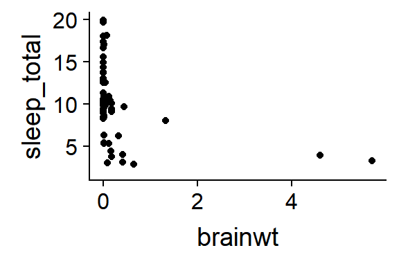

Mammal sleep, raw data

```r
qplot(y = sleep_total,
      x = brainwt,
      data = msleep)
```

That looks really really ugly. It will work better if we “log transform the axes”

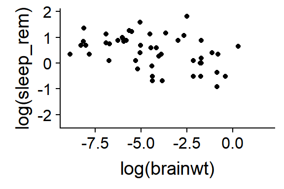

Mammal sleep, logged data

```r
qplot(y = log(sleep_rem),
      x = log(brainwt),
      data = msleep)
```

Things get logged all the time in stats. We’ll talk more about that later.

### Add color coding to scatterplot

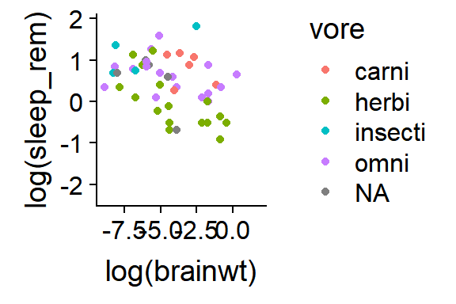

Add colors with color =

```r
qplot(y = log(sleep_rem),
      x = log(brainwt),
      data = msleep,
      color = vore)
```

### Add color & shape coding to scatterplot

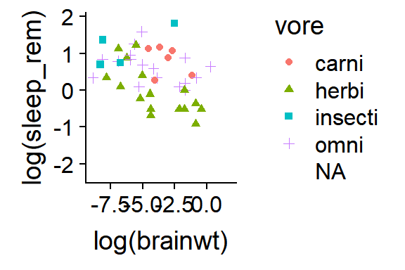

Add shapes with shape =

```r
qplot(y = log(sleep_rem),
      x = log(brainwt),
      data = msleep,
      color = vore,
      shape = vore)
```

### Put diffetrent “vores” in seperate panels

- Seperate panels can be made using the “facet” arguement withing qplot

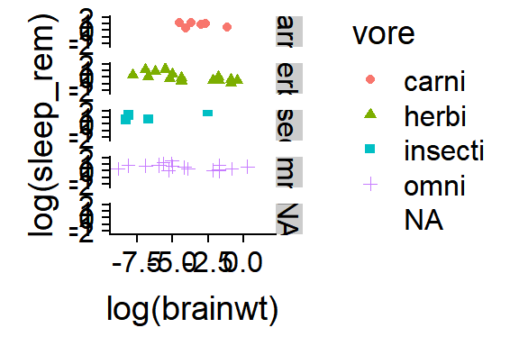

Split into different panels w/ facets =

```r
qplot(y = log(sleep_rem),
      x = log(brainwt),
      data = msleep,
      color = vore,
      shape = vore,
      facets = vore ~ .)
```

### Add a “trend line”" to a scatterplot

- Add the geom_smooth() function after the initial qplot() command
- This works best if we remove the “color = vore” command, but you can see what happens if you leave it

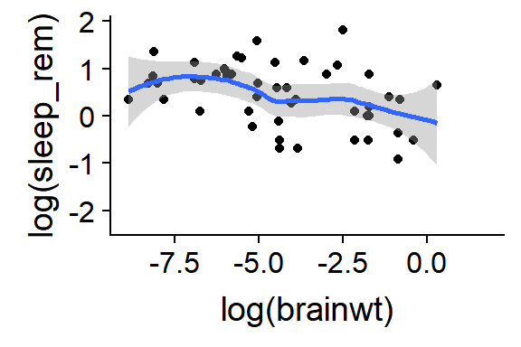

Add trendline with + geom_smooth()

```r
qplot(y = log(sleep_rem),
      x = log(brainwt),
      data = msleep) +
  geom_smooth()
```

### Exercise: Modify mammal brain code to do the following things

- Change the axes labels
- Add a title
- Use names(msleep) to see what other varibles are in the dataset
- Use summary(msleep) to whether they are continous or categorical
- Pick another continous variable and plot it instead of sleep_total
- Try this with and without logging